# Grappling with the “Body awareness” scale

Last updated 2018-04-07

# Differences across fieldsites

## Mean scores by site

First, let’s look at scores for participants in each site:

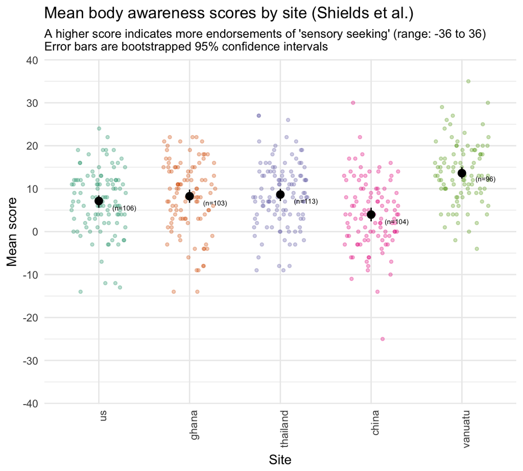

Note that this plot includes both average scores for each site (in black), and individual scores for all of the participants in that site (small, colorful points in the background, which are “jittered” around a little so that you can see them all).

Looks like people in different sites responded somewhat differently to this scale, but the differences are pretty subtle. Participants in Vanuatu responded substantially more positively; participants in China and maybe the US somewhat more neutrally/negatively.

Now let’s look at these differences in more detail using the “raw data” for individual questions, rather than these subscale scores.

## Responses by question, by site

```
Column `question` joining character vector and factor, coercing into character vectorIgnoring unknown aesthetics: fill
```

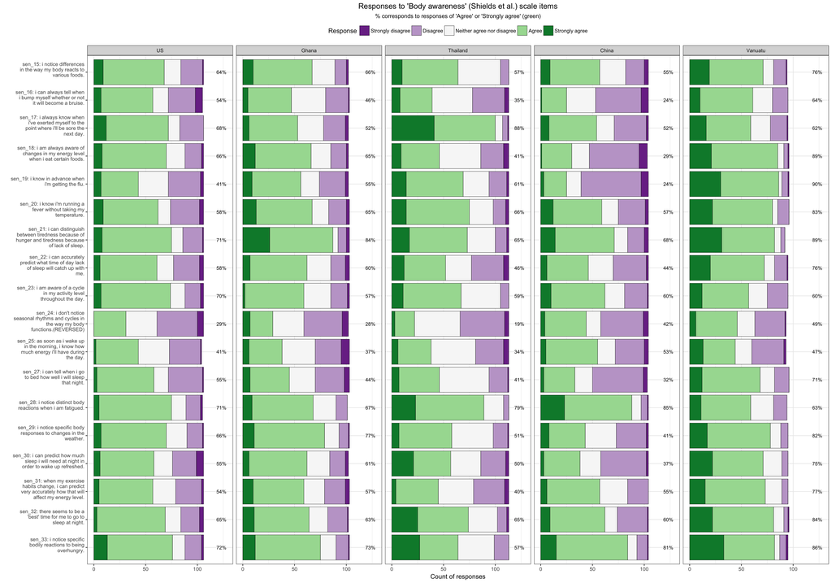

**NOTE**: This scale has **1 reverse-coded item** (`sen_24`), which is *not* reverse-coded in this plot - i.e., if people selected “Disagree” for this item, it’s plotted here as “Disagree.” (For the previous plots of overall “scores,” this item was reverse-coded.)

As always, lots to chew on here. Off the top of my head, a few things stand out:

- More use of the neutral midpoint in TH but not CH, this time.
- At a glance, it seems like people in VT used the “disagree” end of the scale (purple) maybe a little less than others, and hardly ever used the most extreme negative endpoint (“Strongly disagree”)… though let’s also look at this at an individual level (below).
- People in TH agreed exceptionally strongly with the item, “I always know when I’ve exerted myself to the point where I’ll be sore the next day” (`sen_17`). Interesting! What do you make of this, **Felicity**?
- The flu seemed to come out of nowhwere for participants in CH (`sen_19`).
- Participants in GH and VT reported being more attuned to the difference between tiredness due to hunger vs. sleep (`sen_21`).

…and so much more.

Again, **Josh**, you’ve gotta take a look at these with an eye toward a ratio! Maybe we should fold them into the “ratio of senses” doc…

# Distribution of responses for individual participants, by site

Another thing we might be interested in is how individual participants responded: Were there people who said yes to everything, or no to everything? How do these distributions of responses differ across participants in different sites?

Let’s take a look:

```
Column `question` joining character vector and factor, coercing into character vector
```

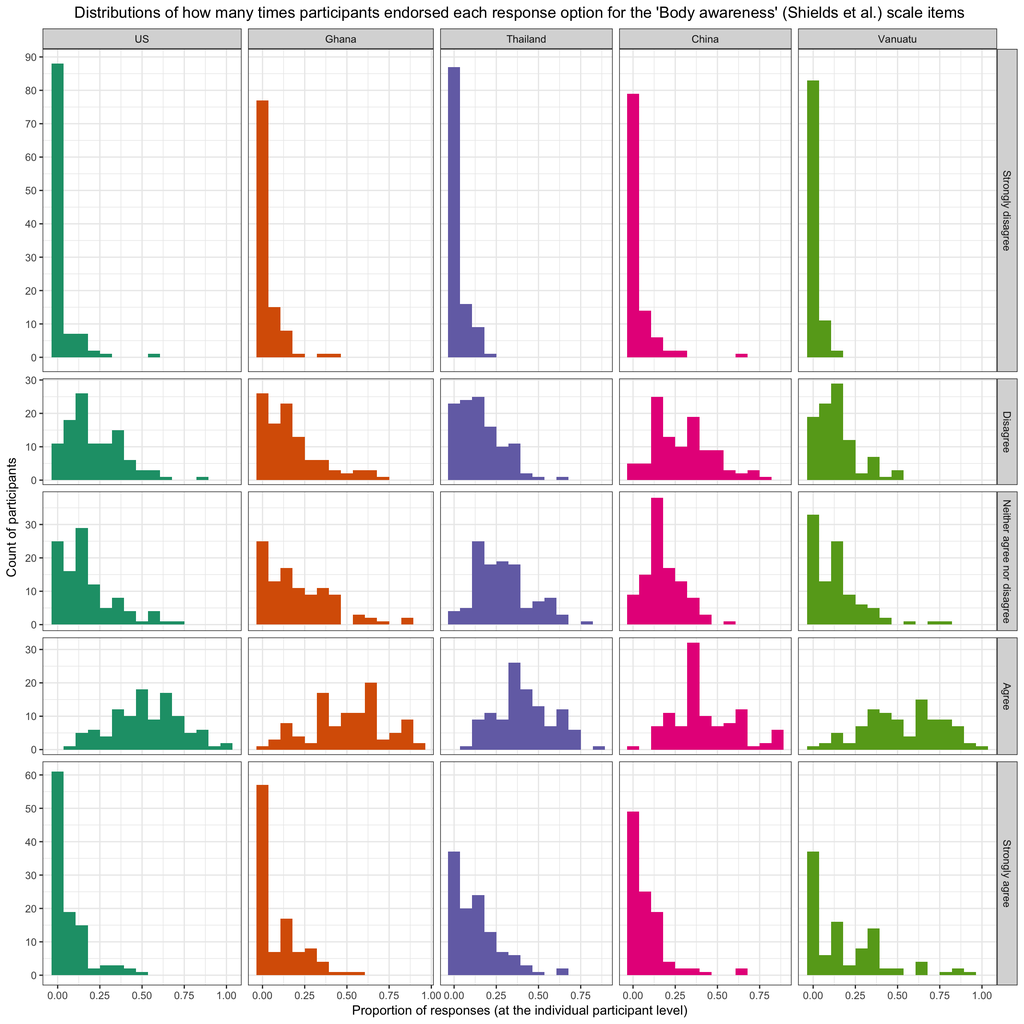

Again, lots to sort through here.

Just for fun, here’s another way to look at the same data, overlaying the density distributions for each site on top of each other to see where they seem to be similar/different:

```
Column `question` joining character vector and factor, coercing into character vector
```

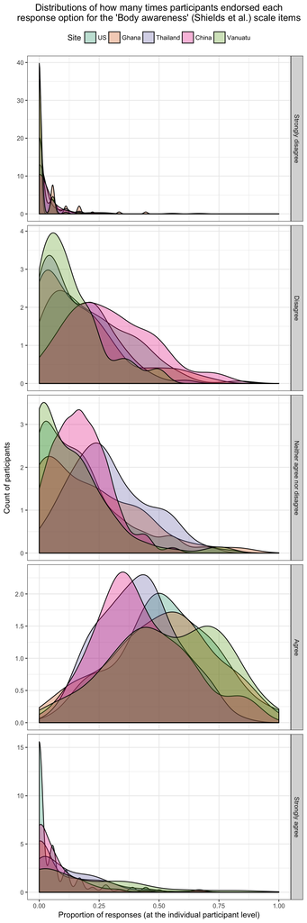